# taxify: messy name lists to accepted names, offline

Gilles Colling

BioInva people meeting, 25 June 2026

## What this solves

- Every dataset here starts as a name column. Resolving it to accepted names in R, at scale and offline, is the job.
- A plain `merge()` on raw strings silently drops every disagreeing row, so the matching has to come first.
- `taxify` returns one standardized table from a character vector: cleaned, matched against a backbone you keep on disk, synonyms resolved. Matching runs in C, so no web services, no rate limits, and the same input gives the same output on any machine.

Below: each job done the familiar way and with taxify, side by side. Everything runs offline against the staged backbone.

## Setup

```r
install.packages("pak")
pak::pak("gcol33/taxify")     # the vectra engine installs with it
```

The first `taxify()` call downloads the WFO backbone once (about 150 MB, roughly 1 GB once unpacked). After that the package never touches the network. To stage it deliberately:

```r
library(taxify)
taxify_download_vtr("wfo")
taxify_data_dir()             # where the backbone lives on this machine
```

## One call

Hand `taxify()` a character vector. It cleans each name, matches it, and resolves synonyms.

```r
field_names <- c(
  "Quercus robur L.",        # authorship to strip
  "Quercus robus",           # typo
  "cf. Betula pendula",      # field qualifier
  "FAGUS SYLVATICA",         # caps
  "Quercus pedunculata",     # historical synonym of Q. robur
  "Q. petraea",              # abbreviated genus
  "Pinus abies",             # synonym of Picea abies (a different genus)
  "Festuca rubrra",          # typo
  "Fallopia japonica",       # synonym of Reynoutria japonica (invasive)
  "Taraxacum officinale"
)

res <- taxify(field_names)
res[, c("input_name", "accepted_name", "family",
        "is_synonym", "match_type", "fuzzy_dist")]
```

```
#>              input_name        accepted_name       family is_synonym match_type
#> 1      Quercus robur L.        Quercus robur     Fagaceae      FALSE      exact
#> 2         Quercus robus        Quercus robur     Fagaceae      FALSE      fuzzy
#> 3    cf. Betula pendula       Betula pendula   Betulaceae      FALSE      exact
#> 4       FAGUS SYLVATICA      Fagus sylvatica     Fagaceae      FALSE   exact_ci
#> 5   Quercus pedunculata        Quercus robur     Fagaceae       TRUE      exact
#> 6            Q. petraea      Quercus petraea     Fagaceae      FALSE     abbrev
#> 7           Pinus abies          Picea abies     Pinaceae       TRUE      exact
#> 8        Festuca rubrra        Festuca rubra      Poaceae      FALSE      fuzzy
#> 9     Fallopia japonica  Reynoutria japonica Polygonaceae       TRUE      exact
#> 10 Taraxacum officinale Taraxacum officinale   Asteraceae      FALSE      exact
#>    fuzzy_dist
#> 1          NA
#> 2  0.07692308
#> 3          NA
#> 4          NA
#> 5          NA
#> 6          NA
#> 7          NA
#> 8  0.07142857
#> 9          NA
#> 10         NA
```

Ten names, ten rows. The list is small on purpose: each name takes a different route, so the whole table fits on screen and you can read every match. The hundred-name run further down shows how the same call behaves at field size.

Each row carries:

- the original string and the accepted name
- family, genus, and authorship
- a synonym flag and the match type (`exact`, `exact_ci`, `fuzzy`, `abbrev`, `none`)
- the fuzzy distance

[interactive chart not shown]

What happened to each name:

- `Quercus robur L.` lost its authorship before matching.
- `Quercus robus` and `Festuca rubrra` were typos; the fuzzy pass corrected both, comparing only against other *Quercus* and *Festuca* (genus-blocked), so a one-letter slip costs little.
- `cf. Betula pendula` lost the field qualifier.
- `FAGUS SYLVATICA` matched after case folding (`exact_ci`).
- `Quercus pedunculata`, `Pinus abies`, and `Fallopia japonica` resolved to their accepted names (*Quercus robur*, *Picea abies*, *Reynoutria japonica*) with `is_synonym` TRUE. The second crosses a genus boundary, the third is the current name for a well-known invader.
- `Q. petraea` resolved to *Quercus petraea* on the genus initial plus epithet (`match_type` `abbrev`).

## Why a typo barely costs anything

The fuzzy pass never compares a name against the whole backbone. It blocks on genus first, so `Quercus robus` is scored only against the other *Quercus* names, and a one-letter slip is found in a handful of comparisons instead of across every name on disk.

[interactive chart not shown]

The default threshold allows about one edit per five characters, so common typos resolve while genuinely different names do not. A large genus is split further: the block key is the genus plus the first two letters of the epithet, which cuts a 31,000-name genus like *Hieracium* into sub-blocks of roughly a thousand, with a genus-only pass behind it so quality is unchanged.

When the typo lands on the genus itself, the genus block never pulls the name, so a second pass re-blocks on the first two letters of the full string. A genus slip that keeps those two letters still resolves to the right name; one that changes them falls through to no match. This second pass runs on the WFO, Catalogue of Life, and GBIF backbones.

[interactive chart not shown]

## Check the batch at a glance

`summary()` prints a digest, which is the fastest way to see whether a run went cleanly or something upstream needs attention.

```r
summary(res)
```

```
#> ── taxify results ────────────────────────────────────────────────────────────
#>   backend: WFO v2024-12  |  10 names submitted
#>
#>   matched        10  (exact: 6, case-insensitive: 1, fuzzy: 2, abbrev: 1)
#>   ────────────────────────────────────────────────────────────
#>   taxon groups: angiosperm: 8  gymnosperm: 1  unknown: 1
```

## Offline, and how much faster

Every match runs against the local snapshot:

- the same input gives the same output on any machine, so a run reproduces exactly
- the `backbone_version` column records the exact WFO release and download date, which drops into a methods section

With the backbone already loaded (after the first call), a hundred-name field list resolves in a fraction of a second on this machine:

```r
field <- c(
  "Quercus petraea", "Pinus sylvestris", "Picea abies", "Betula pendula",
  "Acer pseudoplatanus", "Acer platanoides", "Acer campestre", "Corylus avellana",
  "Fraxinus excelsior", "Carpinus betulus", "Sorbus aucuparia", "Tilia cordata",
  "Ulmus glabra", "Alnus glutinosa", "Salix caprea", "Populus tremula",
  "Prunus avium", "Prunus spinosa", "Crataegus monogyna", "Sambucus nigra",
  "Cornus sanguinea", "Viburnum opulus", "Euonymus europaeus", "Ligustrum vulgare",
  "Frangula alnus", "Juniperus communis", "Taxus baccata", "Larix decidua",
  "Abies alba", "Rosa canina", "Rubus idaeus", "Hedera helix",
  "Clematis vitalba", "Berberis vulgaris", "Betula pubescens", "Prunus padus",
  "Rhamnus cathartica", "Lonicera xylosteum", "Trifolium repens", "Trifolium pratense",
  "Festuca ovina", "Dactylis glomerata", "Plantago lanceolata", "Plantago major",
  "Plantago media", "Achillea millefolium", "Ranunculus acris", "Ranunculus repens",
  "Urtica dioica", "Poa pratensis", "Poa annua", "Galium mollugo",
  "Galium aparine", "Bellis perennis", "Cardamine pratensis", "Cirsium arvense",
  "Cirsium vulgare", "Daucus carota", "Heracleum sphondylium", "Anthriscus sylvestris",
  "Lotus corniculatus", "Medicago lupulina", "Vicia cracca", "Lathyrus pratensis",
  "Stellaria media", "Silene dioica", "Silene vulgaris", "Geranium pratense",
  "Geranium robertianum", "Glechoma hederacea", "Lamium album", "Prunella vulgaris",
  "Ajuga reptans", "Veronica chamaedrys", "Rumex acetosa", "Rumex obtusifolius",
  "Chenopodium album", "Capsella bursa-pastoris", "Senecio vulgaris", "Leucanthemum vulgare",
  "Centaurea jacea", "Knautia arvensis", "Campanula rotundifolia", "Primula veris",
  "Anemone nemorosa", "Filipendula ulmaria", "Lythrum salicaria",
  # a few naturalized aliens this group works with
  "Robinia pseudoacacia", "Solidago canadensis", "Solidago gigantea",
  "Impatiens glandulifera", "Heracleum mantegazzianum", "Prunus serotina",
  "Quercus rubra",
  # and the same kinds of mess as the ten-name list, at scale
  "Quercus robur L.", "FAGUS SYLVATICA", "Quercus robus",
  "cf. Taraxacum officinale", "Quercus pedunculata", "Festuca rubrra"
)

t <- system.time(field_res <- taxify(field, verbose = FALSE))
cat(sprintf("%d names resolved in %.3f s on this machine\n",
            length(field), t[["elapsed"]]))
```

```
#> 100 names resolved in 0.110 s on this machine
```

At this size you stop reading the table row by row. The fastest check is the digest from `summary()` (matched, and by which route); then the only rows that need a human’s eye are the ones that did not match exactly. Filtering to those turns a hundred rows into a handful:

```r
field_res[field_res$match_type != "exact" | field_res$is_synonym %in% TRUE,
          c("input_name", "accepted_name", "match_type",
            "is_synonym", "fuzzy_dist")]
```

```
#>              input_name        accepted_name match_type is_synonym fuzzy_dist
#> 85     Anemone nemorosa Anemonoides nemorosa      exact       TRUE         NA
#> 96      FAGUS SYLVATICA      Fagus sylvatica   exact_ci      FALSE         NA
#> 97        Quercus robus        Quercus robur      fuzzy      FALSE 0.07692308
#> 99  Quercus pedunculata        Quercus robur      exact       TRUE         NA
#> 100      Festuca rubrra        Festuca rubra      fuzzy      FALSE 0.07142857
```

The package benchmark sizes that up. On the same task many in this room reach for, WorldFlora’s `WFO.match`, both run against a local copy and return the same matches; the difference is where the matching happens. taxify scores names in C against the compiled backbone, WorldFlora in R. On 1,000 plant names with fuzzy matching on (Windows, R 4.5.2), the published numbers are:

[interactive chart not shown]

## Add your own attributes

Once names resolve to an accepted name, any table keyed on species joins cleanly. `add_data()`:

- takes a data frame, or a CSV, XLSX, or SQLite file
- runs its species column through the same backbone
- joins on the accepted name, so a synonym on either side still lines up

```r
my_traits <- data.frame(
  species      = c("Quercus pedunculata",   # synonym of Q. robur
                   "Pinus sylvestris",
                   "Betula pendula"),
  seed_mass_mg = c(3200, 7.5, 0.2)
)

taxify(c("Quercus robur", "Pinus sylvestris", "Betula pendula")) |>
  add_data(my_traits, species_col = "species")
```

```
#>         input_name     matched_name    accepted_name       taxon_id
#> 1    Quercus robur    Quercus robur    Quercus robur wfo-0000292858
#> 2 Pinus sylvestris Pinus sylvestris Pinus sylvestris wfo-0000481648
#> 3   Betula pendula   Betula pendula   Betula pendula wfo-0000335449
#>      accepted_id    rank     family   genus    epithet authorship
#> 1 wfo-0000292858 species   Fagaceae Quercus      robur         L.
#> 2 wfo-0000481648 species   Pinaceae   Pinus sylvestris         L.
#> 3 wfo-0000335449 species Betulaceae  Betula    pendula       Roth
#>   accepted_authorship is_synonym is_hybrid match_type fuzzy_dist is_ambiguous
#> 1                <NA>      FALSE     FALSE      exact         NA        FALSE
#> 2                <NA>      FALSE     FALSE      exact         NA        FALSE
#> 3                <NA>      FALSE     FALSE      exact         NA        FALSE
#>   ambiguous_targets backend         backbone_version kingdom_group taxon_group
#> 1              <NA>     wfo wfo:2024-12 (2026-06-24)       plantae  angiosperm
#> 2              <NA>     wfo wfo:2024-12 (2026-06-24)       plantae  gymnosperm
#> 3              <NA>     wfo wfo:2024-12 (2026-06-24)       plantae  angiosperm
#>    life_form qualifier qualifier_position seed_mass_mg
#> 1 angiosperm      <NA>               <NA>       3200.0
#> 2 gymnosperm      <NA>               <NA>          7.5
#> 3 angiosperm      <NA>               <NA>          0.2
#> Sources: WFO 2024-12, my_traits | cite() for full citations
```

The trait table used *Quercus pedunculata* and the result used *Quercus robur*; a plain `merge()` would have missed that row. `add_data()` joins on the accepted name, so it lines up.

taxify also ships:

- published trait and status layers (`add_zanne()`, `add_eive()`, `add_diaz_traits()`, `add_iucn()`, and more)
- a fallback chain across backbones for animals, fungi, and marine taxa (`backend = c("wfo", "col", "gbif")`)

The next section lays out the full menu of these layers; the one after stacks three and runs a quick analysis. Full detail is in the [enrichments](https://gillescolling.com/taxify/articles/enrichments.html) and [backends](https://gillescolling.com/taxify/articles/backends.html) vignettes.

## The enrichment layers

Those trait and status layers are just the start. The package ships the same join for many more datasets, across the tree of life and for the conservation and invasion records this group works with. Each `add_*()` matches its own source against the backbone and attaches on the accepted name, so any of them stacks into a pipeline the same way.

[interactive chart not shown]

The current layers, grouped by what they cover:

| covers | layers |
| --- | --- |
| Plants | `add_zanne()`, `add_eive()`, `add_diaz_traits()`, `add_leda()`, `add_wcvp()`, `add_glonaf()` |
| Birds & mammals | `add_avonet()`, `add_elton_traits()`, `add_pantheria()` |
| Amphibians & reptiles | `add_amphibio()`, `add_repttraits()` |
| Fish | `add_fishmorph()`, `add_fishbase()` |
| Arthropods | `add_arthropod_traits()`, `add_leptraits()` |
| Fungi | `add_fungal_traits()`, `add_funguild()` |
| Algae | `add_algae_traits()` |
| Cross-taxon animals | `add_animaltraits()`, `add_anage()` |
| Status, alien & names | `add_iucn()`, `add_griis()`, `add_alien_first_records()`, `add_common_names()` |

For invasion work the GloNAF, GRIIS, and alien-first-record layers attach naturalized status, invasive status, and first-record years on the same accepted name, so a resolved species list carries its invasion history without a second join.

## Add published attributes, then test an idea

Pick any three of these and stack them. Woodiness (woody or herbaceous), the five EIVE ecological indicator values (Dengler et al. 2023), and plant height from the Diaz global trait dataset (Diaz et al. 2022) all attach to the same hundred-name field list from above; once attached, the table is ready for ordinary R statistics straight away:

```r
dat <- field_res |>
  add_zanne() |>
  add_eive() |>
  add_diaz_traits()

head(dat[, c("accepted_name", "woodiness", "eive_light", "eive_reaction",
             "eive_nutrients", "plant_height_m")], 10)
```

```
#>          accepted_name woodiness eive_light eive_reaction eive_nutrients
#> 1      Quercus petraea     woody   5.826045      4.792116       3.548459
#> 2     Pinus sylvestris     woody   7.101249      5.133071       2.691805
#> 3          Picea abies     woody   4.362537      4.243331       4.311589
#> 4       Betula pendula     woody   6.840881      4.384956       3.641275
#> 5  Acer pseudoplatanus     woody   3.798876      5.919569       6.891850
#> 6     Acer platanoides     woody   3.871987      6.337649       5.656169
#> 7       Acer campestre     woody   5.046531      6.804980       5.790993
#> 8     Corylus avellana     woody   5.411088      5.743586       5.677502
#> 9   Fraxinus excelsior     woody   4.523195      7.190141       6.980345
#> 10    Carpinus betulus     woody   3.652234      5.623408       5.340294
#>    plant_height_m
#> 1       31.438500
#> 2       19.027893
#> 3       40.688265
#> 4       12.024730
#> 5       24.462656
#> 6       21.925662
#> 7       12.217433
#> 8        3.929159
#> 9       23.115589
#> 10      16.718244
```

Three layers attached in one pipeline (only the first ten rows shown). A few species lack an EIVE or a height value, so those cells are `NA`; R’s statistics functions drop incomplete rows on their own, and the columns are ready to use.

### A correlation

Do species on more base-rich soils also sit higher on the nutrient axis? Two EIVE columns and one `cor.test()`:

```r
cor.test(dat$eive_reaction, dat$eive_nutrients)
```

```
#>
#>  Pearson's product-moment correlation
#>
#> data:  dat$eive_reaction and dat$eive_nutrients
#> t = 3.2378, df = 96, p-value = 0.001654
#> alternative hypothesis: true correlation is not equal to 0
#> 95 percent confidence interval:
#>  0.1230070 0.4821711
#> sample estimates:
#>       cor
#> 0.3137695
```

The trend is positive and, across a hundred species, significant, though modest in strength: base-rich soils tend to carry higher nutrient values.

### A linear model

The same question as a regression returns the slope and the same p-value:

```r
summary(lm(eive_nutrients ~ eive_reaction, data = dat))
```

```
#>
#> Call:
#> lm(formula = eive_nutrients ~ eive_reaction, data = dat)
#>
#> Residuals:
#>     Min      1Q  Median      3Q     Max
#> -4.9207 -1.1559 -0.0833  1.2259  3.5102
#>
#> Coefficients:
#>               Estimate Std. Error t value Pr(>|t|)
#> (Intercept)     2.4460     0.9035   2.707  0.00803 **
#> eive_reaction   0.4816     0.1487   3.238  0.00165 **
#> ---
#> Signif. codes:  0 '***' 0.001 '**' 0.01 '*' 0.05 '.' 0.1 ' ' 1
#>
#> Residual standard error: 1.709 on 96 degrees of freedom
#>   (2 observations deleted due to missingness)
#> Multiple R-squared:  0.09845,    Adjusted R-squared:  0.08906
#> F-statistic: 10.48 on 1 and 96 DF,  p-value: 0.001654
```

Each unit of soil-reaction value adds about half a point on the nutrient axis and explains roughly a tenth of the variance. For a single predictor the model’s p-value matches the correlation’s.

### An ANOVA

Woodiness is a grouping factor, so an analysis of variance asks whether woody and herbaceous species differ in height:

```r
height <- dat[!is.na(dat$plant_height_m), ]
summary(aov(plant_height_m ~ woodiness, data = height))
```

```
#>             Df Sum Sq Mean Sq F value   Pr(>F)
#> woodiness    1   4699    4699   81.74 1.85e-14 ***
#> Residuals   95   5461      57
#> ---
#> Signif. codes:  0 '***' 0.001 '**' 0.01 '*' 0.05 '.' 0.1 ' ' 1
```

```r
tapply(height$plant_height_m, height$woodiness, mean)
```

```
#> herbaceous      woody
#>  0.5024754 14.4593877
```

Woody species average about fourteen metres against half a metre for the herbs, a difference that is clearly significant here. The result is unsurprising for height; the same three lines work for any attribute the package can attach. A boxplot shows the split:

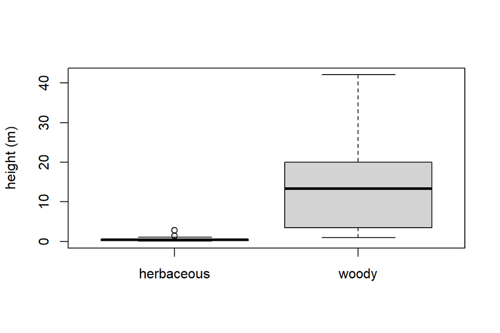

```r
boxplot(plant_height_m ~ woodiness, data = height,
        ylab = "height (m)", xlab = "")
```